# Fitness_Data_Analysis

Yibo Yuan

12/14/2020

```r
library(ggplot2)
library(dplyr)
require(tidyverse)
require(randomForest)
require(ggpubr)
require(reshape2)
library("FactoMineR")
library("factoextra")
```

## Cleaning the data

```r
df = read.csv('fa.csv')
names(df)
```

```
##  [1] "Your.name"
##  [2] "Your.gender"
##  [3] "Your.age"
##  [4] "How.important.is.exercise.to.you.."
##  [5] "How.do.you.describe.your.current.level.of.fitness.."
##  [6] "How.often.do.you.exercise."
##  [7] "What.barriers..if.any..prevent.you.from.exercising.more.regularly.............Please.select.all.that.apply."
##  [8] "What.form.s..of.exercise.do.you.currently.participate.in...........................Please.select.all.that.apply."
##  [9] "Do.you.exercise.___________.."
## [10] "What.time.if.the.day.do.you.prefer.to.exercise."
## [11] "How.long.do.you.spend.exercising.per.day.."
## [12] "Would.you.say.you.eat.a.healthy.balanced.diet.."
## [13] "What.prevents.you.from.eating.a.healthy.balanced.diet..If.any...........................Please.select.all.that.apply."
## [14] "How.healthy.do.you.consider.yourself."
## [15] "Have.you.ever.recommended.your.friends.to.follow.a.fitness.routine."
## [16] "Have.you.ever.purchased.a.fitness.equipment."
## [17] "What.motivates.you.to.exercise...........Please.select.all.that.applies.."
```

```r
names(df) <- c('name','gender','age','importance','fitness_level','exercise_f','excuse',
               'type','size','time','length','diet','diet_excuse','healthy','friends','equipment',
               'motivation')
df$gender <- as.factor(df$gender)
df$age <- as.factor(df$age)
df$importance <- as.factor(df$importance)
df$fitness_level <- as.factor(df$fitness_level)
df$exercise_f <- as.factor(df$exercise_f)
df$size <- as.factor(df$size)
df$time <- as.factor(df$time)
df$length <- as.factor(df$length)
df$diet <- as.factor(df$diet)
df$healthy <- as.factor(df$healthy)
df$friends <- as.factor(df$friends)
df$equipment <- as.factor(df$equipment)
```

## Transform data structure to turn multiple choices answers into individual variable.

Transforming variable:What barriers, if any, prevent you from exercising more regularly? (Select all that applies) resulting in new dataset called ‘excu’ containing 6 variables, each variable represent one unique answer to the original survey question.The value ‘0’ from each row means that particular answers was not selected at the original survey question, and vice versa.

```r
lev <- levels(factor(df$excuse))
lev <- unique(unlist(strsplit(lev,  ";")))
mnames <- gsub(" ","_", paste("exc", lev , sep = "."))
excu <- matrix(data = "0" , nrow = length(df$excuse), ncol = length(lev))
char.var <- as.character(df$excuse)
for (i in 1:length(lev)) {
  excu[grep(lev[i], char.var , fixed = TRUE), i] <- "1"
}
excu <- data.frame(excu, stringsAsFactors = TRUE)
colnames(excu) <- mnames
summary(excu)
```

```
##  exc.I'll_become_too_tired exc.I_don't_really_enjoy_exercising
##  0:433                     0:486
##  1:112                     1: 59
##  exc.I_have_an_injury exc.Laziness exc.I'm_too_lazy
##  0:514                0:538        0:544
##  1: 31                1:  7        1:  1
##  exc.I_always_busy_with_my_regular_works exc.I_am_lazy
##  0:544                                   0:544
##  1:  1                                   1:  1
##  exc.I_can't_stay_motivated exc.I_exercise_regularly_with_no_barriers
##  0:367                      0:478
##  1:178                      1: 67
##  exc.Laziness_ exc.Laziness_mostly_ exc.I_don't_have_enough_time
##  0:541         0:543                0:255
##  1:  4         1:  2                1:290
##  exc.Less_stamina exc.I_am_not_regular_in_anything exc.No_gym_near_me
##  0:544            0:544                            0:544
##  1:  1            1:  1                            1:  1
##  exc.Travel exc.Allergies exc.Lazy exc.My_friends_don't_come_
##  0:543      0:544         0:544    0:544
##  1:  2      1:  1         1:  1    1:  1
##  exc.Travel_time_I_skip
##  0:544
##  1:  1
```

```r
excu <- excu[,c("exc.I'll_become_too_tired","exc.I_don't_have_enough_time"
              ,"exc.I_can't_stay_motivated","exc.I_have_an_injury"
                ,"exc.I_don't_really_enjoy_exercising","exc.I_exercise_regularly_with_no_barriers")]
```

Transforming variable:What forms of exercise do you currently participate in? (Select all that applies) resulting in new dataset called ‘ty’ containing 8 variables, each variable represent one unique answer to the original survey question.The value ‘0’ from each row means that particular answers was not selected at the original survey question, and vice versa.

```r
lev1 <- levels(factor(df$type))
lev1 <- unique(unlist(strsplit(lev1,";")))
mnames1 <- gsub(" ","_" , paste("type" , lev1 , sep = "."))
ty <- matrix(data = "0" , nrow = length(df$type), ncol = length(lev1))
char.var1 <- as.character(df$type)
for (i in 1:length(lev1)) {
  ty[grep(lev1[i],char.var1,fixed = TRUE), i] <- "1"
}
ty <- data.frame(ty, stringsAsFactors = TRUE)
colnames(ty) <- mnames1
summary(ty)
```

```
##  type.Gym type.Lifting_weights type.Team_sport type.Swimming type.Yoga
##  0:405    0:498                0:452           0:504         0:464
##  1:140    1: 47                1: 93           1: 41         1: 81
##  type.Zumba_dance type.I_don't_really_exercise type.Walking_or_jogging
##  0:512            0:455                        0:221
##  1: 33            1: 90                        1:324
```

Transforming variable:What prevents you from eating a healthy balanced diet, if any? (Select all that applies) resulting in new dataset called ‘dit’ containing 5 variables, each variable represent one unique answer to the original survey question.The value ‘0’ from each row means that particular answers was not selected at the original survey question, and vice versa.

```r
lev2 <- levels(factor(df$diet_excuse))
lev2 <- unique(unlist(strsplit(lev2 , ";")))
mnames2 <- gsub(" ","_" , paste("diet", lev2, sep = "."))
dit <- matrix(data = "0", nrow = length(df$diet_excuse), ncol = length(lev2))
char.var2 <- as.character(df$diet_excuse)
for (i in 1:length(lev2)) {
  dit[grep(lev2[i], char.var2, fixed = TRUE), i] <- "1"
}
dit <- data.frame(dit, stringsAsFactors = TRUE)
colnames(dit) <- mnames2
summary(dit)
```

```
##  diet.Alcohol_does_me_a_good_diet diet.Cost diet.Ease_of_access_to_fast_food
##  0:544                            0:514     0:382
##  1:  1                            1: 31     1:163
##  diet.Temptation_and_cravings diet.I_have_a_balanced_diet
##  0:226                        0:500
##  1:319                        1: 45
##  diet.I_do_not_measure._I_can't_say_for_sure_if_my_diet_is_balanced._
##  0:544
##  1:  1
##  diet.i_don't_have_a_proper_diet diet.Lack_of_time diet.Rarely_eat_fast_food
##  0:544                           0:415             0:544
##  1:  1                           1:130             1:  1
##  diet.Social_circle_
##  0:544
##  1:  1
```

```r
dit <- dit[,c("diet.Lack_of_time" ,"diet.Ease_of_access_to_fast_food","diet.Cost","diet.Temptation_and_cravings"
              ,"diet.I_have_a_balanced_diet")]
```

```r
lev3 <- levels(factor(df$motivation))
lev3 <- unique(unlist(strsplit(lev3, ";")))
mnames3 <- gsub(" ","_", paste("moti" , lev3 , sep = "."))
motiv <- matrix(data = "0" , nrow = length(df$motivation), ncol = length(lev3))
char.var3 <- as.character(df$motivation)
for (i in 1:length(lev3)) {
  motiv[grep(lev3[i], char.var3, fixed = TRUE), i] <- "1"
}
motiv <- data.frame(motiv, stringsAsFactors = TRUE)
colnames(motiv) <- mnames3
summary(motiv)
```

```
##  moti.Going_to_class_on_time_ðŸ\230‰
##  0:544
##  1:  1
##  moti.Gotta_get_that_alcohol_and_****_out_of_the_system
##  0:544
##  1:  1
##  moti.I'm_sorry_..._I'm_not_really_interested_in_exercising
##  0:503
##  1: 42
##  moti.I_dont_wanna_gain_weightðŸ\230‰ moti.I_want_to_achieve_a_sporting_goal
##  0:544                             0:491
##  1:  1                             1: 54
##  moti.I_want_to_be_fit
##  0:204
##  1:341
##  moti.Exercising_gives_you_discipline_and_focus_and_removed_bad_thoughts_from_your_mind.
##  0:544
##  1:  1
##  moti.I_want_to_be_flexible moti.I_want_to_relieve_stress
##  0:372                      0:372
##  1:173                      1:173
##  moti.To_maintain_healthy_body_and_mind
##  0:544
##  1:  1
##  moti.I_want_to_increase_muscle_mass_and_strength moti.I_want_to_lose_weight
##  0:456                                            0:347
##  1: 89                                            1:198
##  moti.Doing_exercises_prevents_many_diseases.So_yeah_saves_a_lot_of_money_.
##  0:544
##  1:  1
##  moti.I_want_to_look_young_and_think_young moti.Control_Diabetes_
##  0:544                                     0:544
##  1:  1                                     1:  1
##  moti.I_want_to_think_clearly_and_I_want_to_play_cricket_with_my_grandkids
##  0:544
##  1:  1
##  moti.My_dad_motivates_me_ moti.Not_doing_exercise moti.Personal_reasons
##  0:544                     0:544                   0:544
##  1:  1                     1:  1                   1:  1
##  moti.Reaching_class_on_time_ðŸ\230…
##  0:544
##  1:  1
##  moti.See_the_answer_to_what_barriers,_if_any,_prevent_you_from_exercising__regularly_
##  0:544
##  1:  1
```

```r
motiv <- motiv[,c("moti.I_want_to_be_fit","moti.I_want_to_increase_muscle_mass_and_strength"
                ,"moti.I_want_to_lose_weight","moti.I_want_to_be_flexible"
                ,"moti.I_want_to_relieve_stress"
                ,"moti.I_want_to_achieve_a_sporting_goal"
                ,"moti.I'm_sorry_..._I'm_not_really_interested_in_exercising")]
summary(motiv)
```

```
##  moti.I_want_to_be_fit moti.I_want_to_increase_muscle_mass_and_strength
##  0:204                 0:456
##  1:341                 1: 89
##  moti.I_want_to_lose_weight moti.I_want_to_be_flexible
##  0:347                      0:372
##  1:198                      1:173
##  moti.I_want_to_relieve_stress moti.I_want_to_achieve_a_sporting_goal
##  0:372                         0:491
##  1:173                         1: 54
##  moti.I'm_sorry_..._I'm_not_really_interested_in_exercising
##  0:503
##  1: 42
```

combining transformed dataset with original dataset with original survey questions as variables columns deleted.

```r
df <- cbind(df[,-c(7, 8, 13, 17)],excu,ty,dit,motiv)
head(df)
```

```
##        name gender          age importance fitness_level          exercise_f
## 1   Parkavi Female     19 to 25          2          Good               Never
## 2  Nithilaa Female     19 to 25          4     Very good               Never
## 3 Karunya v Female     15 to 18          3          Good 1 to 2 times a week
## 4   Anusha  Female     15 to 18          4          Good 3 to 4 times a week
## 5  Nikkitha Female     19 to 25          3         Unfit               Never
## 6    Girija Female 40 and above          5       Average 3 to 4 times a week
##                      size          time                  length       diet
## 1 I don't really exercise Early morning I don't really exercise Not always
## 2            With a group Early morning I don't really exercise Not always
## 3                   Alone Early morning              30 minutes Not always
## 4                   Alone       Evening                  1 hour        Yes
## 5 I don't really exercise       Evening I don't really exercise        Yes
## 6            With a group       Evening                  1 hour Not always
##   healthy friends equipment exc.I'll_become_too_tired
```

[output cut: 76 more lines]

motivation for exercise between male and female group

[figure not shown]

```r
newdata <- df %>%
  select(2,33:39)

d4 <- melt(newdata,id = 'gender')
d5 <- d4[d4$value == 1,]
ggplot(d5,aes(variable,fill = gender)) + geom_bar(position = 'dodge')+
  scale_x_discrete(name = "Motivation for Exercise",labels = c("Not interested in exercising",
                            "Achieving sporting goal",
                            "Stress relieve",
                            "To be more flexible",
                            "To lose weight",
                            'Enhance muscle mass and strength',
                            'To be fit')) + coord_flip()
```

exercise type between male and female group

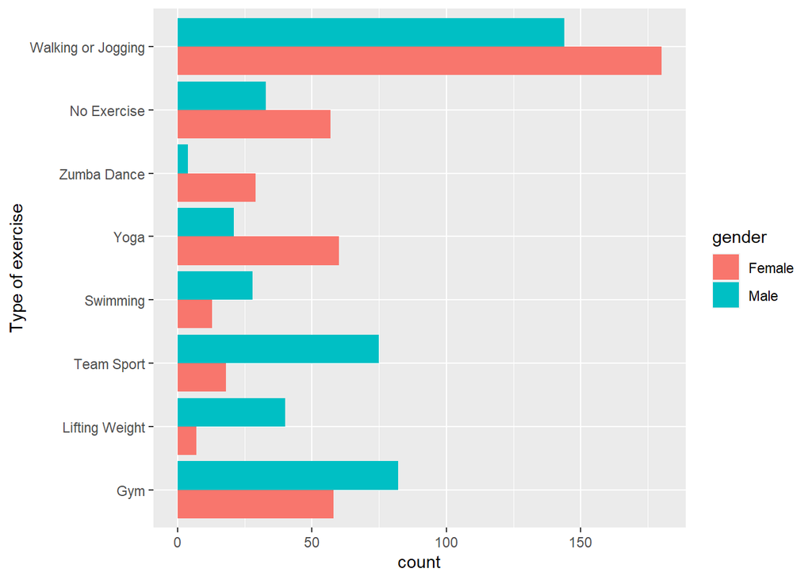

```r
newdata1 <- df %>%
  select(2,20:27)

ty.long <- melt(newdata1,id = 'gender')
ty1 <- ty.long[ty.long$value == 1,]
ggplot(ty1,aes(variable,fill = gender)) + geom_bar(position = 'dodge') +
  scale_x_discrete(name = "Type of exercise",labels = c("Gym",
                                                    "Lifting Weight",
                                                    "Team Sport",
                                                    "Swimming",
                                                    "Yoga",
                                                    'Zumba Dance',
                                                    'No Exercise',
                                                    'Walking or Jogging')) + coord_flip()
```

Does a person tend to exercise more with group or alone?

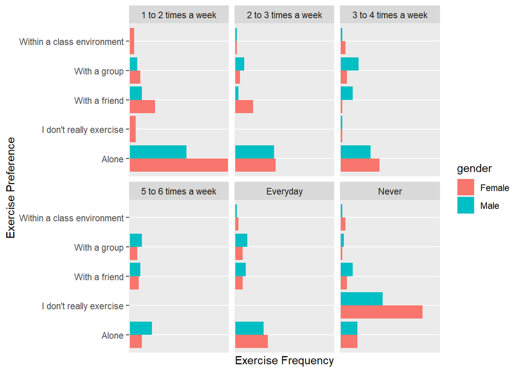

```r
ggplot(df,aes(size,fill = gender)) + geom_bar(position = 'dodge') +
  scale_x_discrete(name = "Exercise Preference") +
  scale_y_discrete(name = "Exercise Frequency") + coord_flip() +
  facet_wrap( ~ exercise_f)
```

Does female see the importance of exercise different than male?

```r
chisq.test(table(df$gender,df$importance),simulate.p.value = T)
```

```
##
##  Pearson's Chi-squared test with simulated p-value (based on 2000
##  replicates)
##
## data:  table(df$gender, df$importance)
## X-squared = 13.962, df = NA, p-value = 0.007496
```

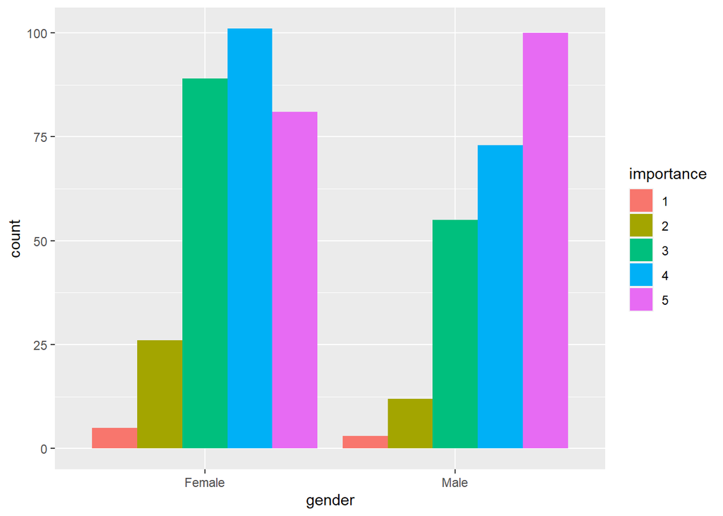

```r
ggplot(df,aes(gender,fill = importance)) + geom_bar(position = 'dodge')
```

Does the perceived importance of exercise vary based on age group?

```r
chisq.test(table(df$age,df$importance),simulate.p.value = T)
```

```
##
##  Pearson's Chi-squared test with simulated p-value (based on 2000
##  replicates)
##
## data:  table(df$age, df$importance)
## X-squared = 33.042, df = NA, p-value = 0.01049
```

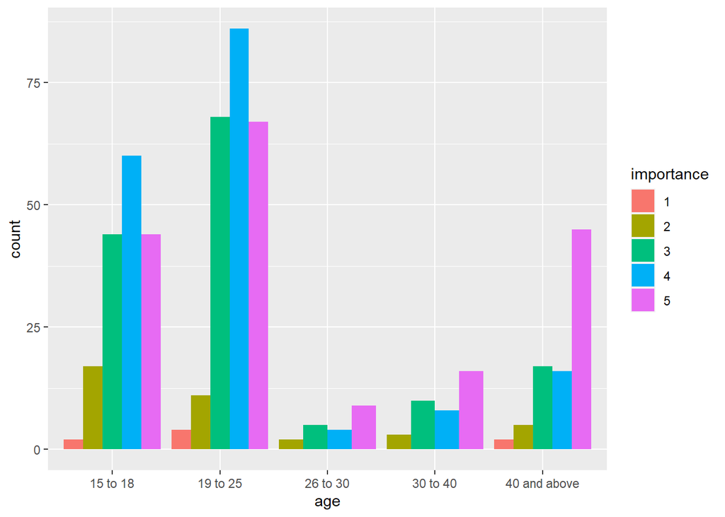

```r
ggplot(df,aes(age,fill = importance)) + geom_bar(position = 'dodge')
```

```r
model <- lm(as.numeric(healthy)~-1,data = df)
model
```

```
##
## Call:
## lm(formula = as.numeric(healthy) ~ -1, data = df)
##
## No coefficients
```